# LibreOffice Base

[LibreOffice Base](https://www.libreoffice.org/discover/base/) is an open source RDBMS (relational database management system) front-end tool to create and manage various databases.

## Preparing the ODBC Connection

First, make sure to prepare MariaDB Connector/ODBC as explained in MariaDB Connector/ODBC.

That includes:

- Download [the latest MariaDB Connector/ODBC](https://mariadb.com/downloads/#connectors)
- Copy the shared library *libmaodbc.so* to */usr/lib/[multi-arch]*
- Install the *unixodbc, unixodbc-dev, openssh-client, odbcinst* packages
- Create a template file for the ODBC driver. A sample *“MariaDB_odbc_driver_template.ini”* could be:

| [MariaDB ODBC 3.1 Driver] |
| --- |
| Description = MariaDB Connector/ODBC v.3.1 |
| Driver = /usr/lib/x86_64-linux-gnu/libmaodbc.so |

- Install the ODBC driver from the template file by running:

```
$ sudo odbcinst -i -d -f MariaDB_odbc_driver_template.ini
odbcinst: Driver installed. Usage count increased to 1.
    Target directory is /etc
```

Verify successful installation in */etc/odbcinst.ini* file (this path is obtained by the config info */-j*/ option, where drivers are installed in that predefined location).

```
$ odbcinst -j
unixODBC 2.3.6
DRIVERS............: /etc/odbcinst.ini
SYSTEM DATA SOURCES: /etc/odbc.ini
FILE DATA SOURCES..: /etc/ODBCDataSources
USER DATA SOURCES..: /home/anel/.odbc.ini
SQLULEN Size.......: 8
SQLLEN Size........: 8
SQLSETPOSIROW Size.: 8

$ cat /etc/odbcinst.ini
[MariaDB ODBC 3.1 Driver]
Description=MariaDB Connector/ODBC v.3.1
Driver=/usr/lib/x86_64-linux-gnu/libmaodbc.so
UsageCount=1
```

- Create a template file for the Data Source Name (DSN). A sample *“MariaDB_odbc_data_source_template.ini”* could be:

[output not shown]

- Install data source:

```
odbcinst -i -s -h -f MariaDB_odbc_data_source_template.ini
```

- Verify successful installation in the */.odbc.ini* file

```
$ cat ~/.odbc.ini
[MariaDB-server]
Description=MariaDB server
Driver=MariaDB ODBC 3.1 Driver
SERVER=MariaDB
USER=anel
PASSWORD=
DATABASE=test
PORT=3306
```

- Verify successful installation also using the isql utility, for example:

```
$ isql MariaDB-server
+---------------------------------------+
| Connected!                            |
|                                       |
| sql-statement                         |
| help [tablename]                      |
| quit                                  |
|                                       |
+---------------------------------------+
SQL> show tables;
+--------------------------------------------------------------------------+
| Tables_in_test                                                           |
+--------------------------------------------------------------------------+
| Authors                                                                  |
| tbl_names                                                                |
| webposts                                                                 |
| webusers                                                                 |
+--------------------------------------------------------------------------+
SQLRowCount returns 4
4 rows fetched
```

## Start with LibreOffice Base

Start Libreoffice Base from the terminal by running *lobase* (make sure to install the *libreoffice-base* package if needed). The default option is to create a new database, which is *HSQLDB*. In order to connect to a running MariaDB server, choose *“Connect to an existing database”* and choose *“ODBC”* driver as shown below:

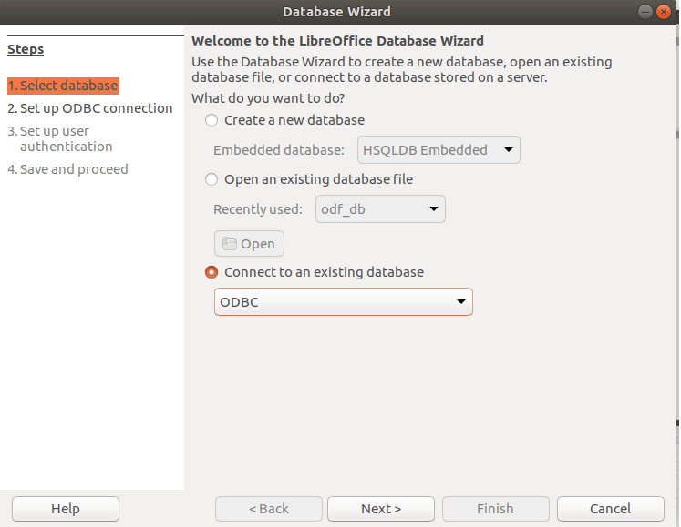

After that, choose DSN (the one that we created in the previous step) and click *“Next”*:

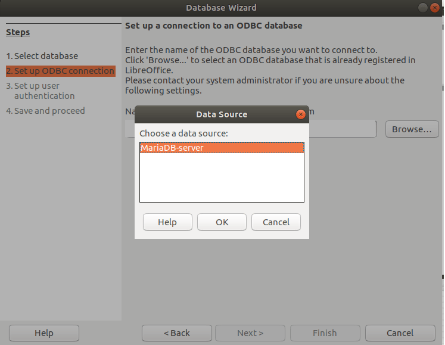

Provide a user name (and password if needed) and again check the connection (with the *“Test Connection”* button) and click *“Next”*:

[figure not shown]

After that, we have options to register the database. Registration in this sense means that the database is viewable by other LibreOffice modules (like *LibreOffice Calc* and *LibreOffice Writer*). So this step is optional. In this example, we will save as *“fosdem21_mariadb.odb”*. See Using a Registered Database.

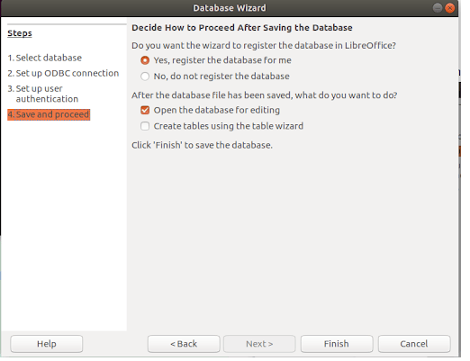

It opens the following window:

[figure not shown]

It consists of three windows/panels:

1. *“Database”* window with the options
   1. *"Tables"*,
   2. *"Queries"*,
   3. *"Forms"*,
   4. *"Reports"*.
2. "Tasks window (dependent on what is selected in the *“Database”* window). When *“Tables”* is selected, the options are:
   1. *"Create Table in Design View"*,
   2. *"Use Wizard to Create Table"* and
   3. *"Create View"*.
3. *"Tables"* window - shows list of tables that are created.

As we can see, there are system tables in the *“mysql”* database as well as *“test”* database.

Let’s say we create a table using the REST API from JSON data from http://jsonplaceholder.typicode.com/posts, and another table using the same mechanism from http://jsonplaceholder.typicode.com/users, and let’s call them *webposts* and *webusers*. In order to do so, we have to enable the **CONNECT** storage engine plugin and start with REST_API. See more in the CONNECT - Files Retrieved Using Rest Queries article.

The queries we need to run in MariaDB are:

```
CREATE TABLE webusers ENGINE=CONNECT TABLE_TYPE=JSON
  HTTP='http://jsonplaceholder.typicode.com/users';

CREATE TABLE webposts ENGINE=CONNECT TABLE_TYPE=JSON
  HTTP='http://jsonplaceholder.typicode.com/posts';
```

The result in LibreOffice Base will be as shown below:

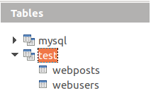

Double clicking on the table opens a new window with the data displayed to inspect:

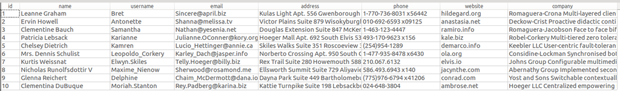

To create the table from the *“Tasks”* window, use the option *“Create Table in Design View”*, where one can specify specific field names and types as shown:

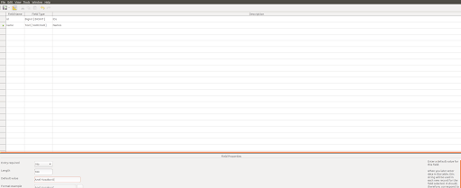

From the “Tasks” window one can create a table using the option *“Use Wizard to Create Table”* to create some sample tables.

One can fill the data in the existing table, or create and define the new table from the *LibreOffice Calc* module with simple copy-paste (in the *"Tasks"* window).

## Using a Registered Database

Other modules can use the registered database, for example, open *"LibreOffice Calc"* and go to *"Tools"*, *"Options"* and you will see the *"odb"* file we registered when starting *"LibreOffice Base"*.